# bipartito Mundo

$$RCA(c,i)= \frac{\displaystyle \frac{x(c,i)}{\displaystyle \sum_{i}x(c,i)}}{\frac{\displaystyle\sum_{c}x(c,i)}{\displaystyle \sum_{c,i}x(c,i)}}
\\$$
dónde $x(c,i)$ es el valor de las exportaciones del **país c** en el **producto i**

```r
library(tidyverse)
library(readxl)
library(ggthemes)
library(viridis)
library(igraph)
library(countrycode)
library(fuzzyjoin)
library(maps)
countrycode_data <- codelist %>% select(country.name.en, cldr.short.es_ar, cldr.short.en,iso3c,region,continent)
```

```r
rel_comp_adv <- function(data, country_filt=NA, digits=4){

  if (digits<5) { #si tiene 5 son los datos originales y me ahorro el calculo
    data <- data %>%
      mutate(SITC = substr(SITC,1,digits)) %>%
      group_by(year, reporter,rep_iso, SITC) %>%
      summarise(value = sum(value))

  }

  #el denominador se calcula con todos los paises
  mean_dist_SITC <- data %>%
    group_by(year, SITC) %>%
    summarise(value = sum(as.numeric(value),na.rm = T)) %>%
    group_by(year) %>%
    mutate(mean_prop = value/sum(value, na.rm = TRUE))

  if (!is.na(country_filt)) { #filtro para elegir resultados solo de una seleccion de paises
    data <- data %>%
    filter(rep_iso %in% country_filt)
  }

  #el denominador despues del filtro
  data <- data %>%
    group_by(year, SITC, rep_iso,reporter) %>%
    summarise(value = sum(as.numeric(value),na.rm = T)) %>%
    group_by(year,rep_iso) %>%
    mutate(prop = value / sum(value, na.rm = TRUE))

  data <- data %>%
    left_join(mean_dist_SITC %>% select(year,SITC,mean_prop),by = c("year", "SITC")) %>%
    mutate(RCA = prop/mean_prop)

  data
}
```

**Costoso computacionalmente**: Se corre en el server

```r
#Leo la info
data <- read_delim(file = "../dataset/Export_World_directo.csv",delim = ",")

RCA <- rel_comp_adv(data = data, digits = 4)

write_delim(RCA,"results/RCA_mundo4d.txt",delim = ",")

rm(data)
rm(mean_dist_SITC)
gc()
```

```r
RCA <- read_delim("results/RCA_mundo4d.txt",delim = ",")
```

Defino como nodos las conexiones donde RCA>1

```r
nodos <- RCA %>%
  filter(RCA>1,reporter != 'Other Asia, nes') %>%  #me quedo un agregado supranacional
  select(year,SITC,rep_iso,reporter)

nodos <- left_join(nodos,countrycode_data %>% select(rep_iso=iso3c, continent, cldr.short.es_ar))
```

Quiero ver cuantos links hay en promedio por nodo

```r
nodos %>%
  group_by(year,reporter) %>%
  summarise(n= n()) %>%
  ungroup() %>%
  summarise(n=mean(n))
```

| n |
| --- |
| 125.4843 |

obs: En Sudamerica (a 4d)

- Brazil 190.42857
- Argentina 177.13636
- Colombia 152.31818
- Peru 134.80000
- Chile 127.42857
- Uruguay 114.90476

Armo el grafo bipartito para 2016

```r
g <- nodos %>%
  filter(year==2016) %>%
  ungroup() %>%
  select(SITC, rep_iso) %>%
  graph_from_data_frame(., directed = T)

V(g)$type <- !bipartite_mapping(g)$type
is_bipartite(g)
```

```
[1] TRUE
```

# proyecto a los países.

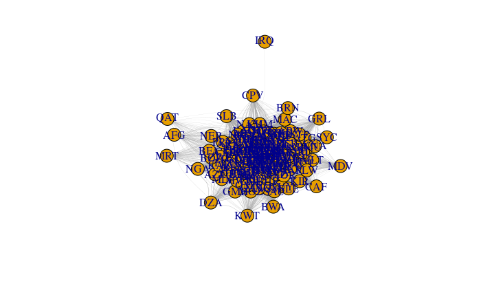

```r
proj <- bipartite_projection(g, which ="false", multiplicity = T)

# pesos <- scale(E(proj)$weight,scale = T)

# V(proj)$color <- "white"
# V(proj)$label <- V(proj)$name
# V(proj)$shape <- "none"
E(proj)$width <- E(proj)$weight/20


plot(proj,edge.curved=runif(length(E(proj)),-0.5,0.5))
```

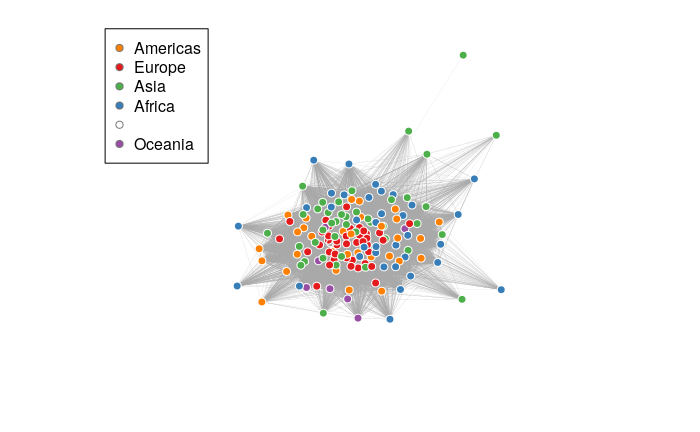

```r
nombres_vertices <- tibble(rt3ISO=as.vector(V(proj)$name))
countrycode_data2 <- countrycode_data %>%
  select(rt3ISO = iso3c, continent)
correspondencia <- left_join(nombres_vertices,countrycode_data2) %>%
  mutate(color = case_when(continent == "Europe" ~"#E41A1C",
                           continent == "Africa" ~"#377EB8",
                           continent == "Asia" ~"#4DAF4A",
                           continent == "Oceania" ~"#984EA3",
                           continent == "Americas" ~"#FF7F00") )
V(proj)$continente <- correspondencia$continent
V(proj)$color <- correspondencia$color
E(proj)$edge.color <- "gray80"

l <-layout_nicely(proj)

plot(proj,edge.arrow.size=.4,vertex.frame.color="#ffffff", edge.size = .5,
     vertex.label="", vertex.label.color="black", vertex.size = 6,
     layout=l)

legend(x=-2,  y=1.2,unique(unique(correspondencia$continent)),
       pch=21,col="#777777",pt.bg=unique(unique(correspondencia$color)))
```

### Cluster

```r
wordmap <- map_data('world')

codes <- tibble(map_regions = unique(wordmap$region),
  map_regions_low = tolower(unique(wordmap$region))) %>%
  regex_left_join(codelist %>%
                    select(pais=iso3c, regex_name = country.name.en.regex), by=c(map_regions_low='regex_name'))
```

```r
plot_map <- function(cluster, method){
  clusters <- tibble(membership=cluster$membership, pais = cluster$names)

  df_map <-  wordmap %>%
    filter(!str_detect(region, "Antarctica")) %>%
    left_join(clusters %>%
    left_join(codes %>% select(pais, region = map_regions))) %>%
    arrange(order) %>%
    mutate(membership = as_factor(membership))


  ggplot(df_map, aes(long, lat)) +
    geom_polygon(aes(group = group,  fill = membership),color="black",size=.1) +
    # coord_quickmap(expand = TRUE) +
    coord_equal(ratio = 1.2)+
    theme_void()+
    theme(legend.position = 'bottom',
         plot.margin = unit(rep(-1.25,4),"lines"),
         text = element_text(size = 20))+
    scale_fill_discrete(glue::glue('Comunidades'))+
    labs(x=NULL, y=NULL, title=NULL)
}
```

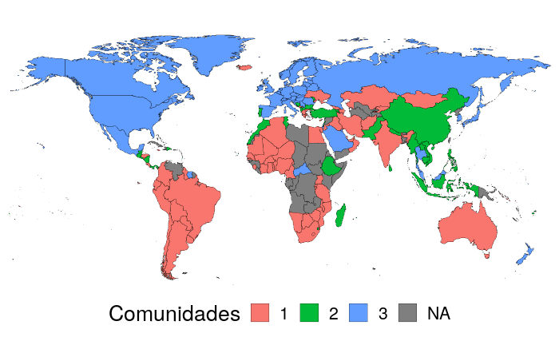

```r
plot_map(walktrap_clust, 'walktrap')
```

## Proyección Productos

# Similitud

Definiciones

$$\large \phi_{ij} = min (P(RCA_i>1/RCA_j>1),P(RCA_j>1/RCA_i>1))
\\$$
dónde $P(RCA_i/RCA_j)$ es la probabilidad condicional de exportar el producto *i* dado que exporta el producto *j*. Para calcular esto, utilizamos lo siguiente:

$$P(RCA_i/RCA_j) = \frac{P(RCA_i = 1 \cap RCA_j = 1)}{P(RCA_j = 1)}$$

$$\text{con } P(RCA_j = 1)= \frac{ \sum_{c} I(RCA_c >1)}{N}$$
siendo N la cantidad de países.

y

$$P(RCA_i = 1 \cap RCA_j = 1) = \frac{\sum_c RCA_i = 1 \cap RCA_j = 1}{N}$$

Lo corro en el server (jupyeter notebook)[calculo_similitud]